# UDEMY COURSES DATASET EDA

## The Business Problem:

### A new course creator wants to create a new udemy course for additional revenue and exposure.

we will use EDA in order to make data based descisions on and answer the following questions:

1. What subject has the best potential?
2. are user feedback and engagement important?
3. what subject niche (keywords) gets the best results?
4. which levels should be targeted with our course?
5. how should we price our course in order to maximize revenue?

```python
df
```

|  | course_id | course_title | url | price | num_subscribers | num_reviews | num_lectures | level | rating | content_duration | published_timestamp | subject | Date | Free/Paid |
| --- | --- | --- | --- | --- | --- | --- | --- | --- | --- | --- | --- | --- | --- | --- |
| 0 | 41295 | Learn HTML5 Programming From Scratch | https://www.udemy.com/learn-html5-programming-... | 0 | 268923 | 8629 | 45 | Beginner Level | 0.82 | 10.5 | 2013-02-14T07:03:41Z | Web Development | 2013-02-14 | Free |
| 1 | 59014 | Coding for Entrepreneurs Basic | https://www.udemy.com/coding-for-entrepreneurs... | 0 | 161029 | 279 | 27 | Expert Level | 0.69 | 3.5 | 2013-06-09T15:51:55Z | Web Development | 2013-06-09 | Free |
| 2 | 625204 | The Web Developer Bootcamp | https://www.udemy.com/the-web-developer-bootcamp/ | 200 | 121584 | 27445 | 342 | Beginner Level | 0.89 | 43.0 | 2015-11-02T21:13:27Z | Web Development | 2015-11-02 | Paid |
| 3 | 173548 | Build Your First Website in 1 Week with HTML5 ... | https://www.udemy.com/build-your-first-website... | 0 | 120291 | 5924 | 30 | All Levels | 0.78 | 3.0 | 2014-04-08T16:21:30Z | Web Development | 2014-04-08 | Free |
| 4 | 764164 | The Complete Web Developer Course 2.0 | https://www.udemy.com/the-complete-web-develop... | 200 | 114512 | 22412 | 304 | Beginner Level | 0.55 | 30.5 | 2016-03-08T22:28:36Z | Web Development | 2016-03-08 | Paid |
| ... | ... | ... | ... | ... | ... | ... | ... | ... | ... | ... | ... | ... | ... | ... |
| 3671 | 885413 | Foundations of Investing | https://www.udemy.com/foundations-of-investing/ | 40 | 0 | 0 | 18 | Beginner Level | 0.95 | 2.0 | 2016-07-27T21:07:46Z | Business Finance | 2016-07-27 | Paid |
| 3672 | 1231958 | 60 Minutes to Fundamental Accounting Skills | https://www.udemy.com/60-minute-fundamental-ac... | 75 | 0 | 0 | 9 | All Levels | 0.95 | 2.5 | 2017-06-28T21:55:29Z | Business Finance | 2017-06-28 | Paid |
| 3673 | 1057040 | Teeter-Totter Accounting | https://www.udemy.com/teeter-totter-accounting/ | 90 | 0 | 0 | 12 | Intermediate Level | 0.36 | 1.0 | 2017-02-08T22:15:56Z | Business Finance | 2017-02-08 | Paid |
| 3674 | 1258666 | Financial Statement Auditing Cycles | https://www.udemy.com/financial-statement-audi... | 50 | 0 | 0 | 9 | All Levels | 0.15 | 2.0 | 2017-06-29T23:20:10Z | Business Finance | 2017-06-29 | Paid |
| 3675 | 1232282 | The Cash Flow Statement - An Introduction | https://www.udemy.com/cash-flow-statement-intr... | 50 | 0 | 0 | 10 | All Levels | 0.18 | 1.5 | 2017-06-28T16:05:51Z | Business Finance | 2017-06-28 | Paid |

3676 rows × 14 columns

first we check for missing values and understand the data types. time based variables will be adjusted.

```python
df.info()
```

```
<class 'pandas.core.frame.DataFrame'>
RangeIndex: 3676 entries, 0 to 3675
Data columns (total 14 columns):
 #   Column               Non-Null Count  Dtype
---  ------               --------------  -----
 0   course_id            3676 non-null   int64
 1   course_title         3676 non-null   object
 2   url                  3676 non-null   object
 3   price                3676 non-null   int64
 4   num_subscribers      3676 non-null   int64
 5   num_reviews          3676 non-null   int64
 6   num_lectures         3676 non-null   int64
 7   level                3676 non-null   object
 8   rating               3676 non-null   float64
 9   content_duration     3676 non-null   float64
 10  published_timestamp  3676 non-null   object
 11  subject              3676 non-null   object
 12  Date                 3676 non-null   object
 13  Free/Paid            3676 non-null   object
dtypes: float64(2), int64(5), object(7)
memory usage: 402.2+ KB
```

```python
df['Date'] = pd.to_datetime(df['Date'])
df['published_timestamp'] = pd.to_datetime(df['published_timestamp'])
```

```python
df.describe()
```

|  | course_id | price | num_subscribers | num_reviews | num_lectures | rating | content_duration | Date |
| --- | --- | --- | --- | --- | --- | --- | --- | --- |
| count | 3.676000e+03 | 3676.000000 | 3676.000000 | 3676.000000 | 3676.000000 | 3676.000000 | 3676.000000 | 3676 |
| mean | 6.757535e+05 | 66.115343 | 3199.260881 | 156.309848 | 40.129761 | 0.610868 | 4.096137 | 2015-11-25 18:43:28.922742272 |
| min | 8.324000e+03 | 0.000000 | 0.000000 | 0.000000 | 0.000000 | 0.000000 | 0.000000 | 2011-07-09 00:00:00 |
| 25% | 4.074740e+05 | 20.000000 | 112.000000 | 4.000000 | 15.000000 | 0.280000 | 1.000000 | 2015-03-15 18:00:00 |
| 50% | 6.876920e+05 | 45.000000 | 912.500000 | 18.000000 | 25.000000 | 0.760000 | 2.000000 | 2016-01-27 00:00:00 |
| 75% | 9.608140e+05 | 95.000000 | 2558.000000 | 67.000000 | 46.000000 | 0.930000 | 4.500000 | 2016-10-29 00:00:00 |
| max | 1.282064e+06 | 200.000000 | 268923.000000 | 27445.000000 | 779.000000 | 1.000000 | 78.500000 | 2017-07-06 00:00:00 |
| std | 3.431304e+05 | 61.056073 | 9486.582966 | 935.674518 | 50.398507 | 0.334287 | 6.054948 | NaN |

### 1. What subject has the best potential?

'revenue' will be used as a KPI to indicate the highest grossing subject.

```python
df['revenue'] = df['price'] * df['num_subscribers']
```

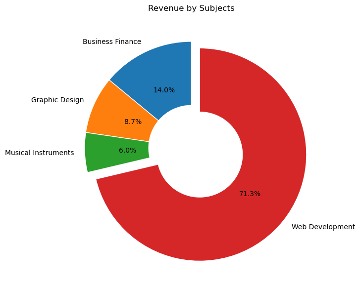

```python
import matplotlib.pyplot as plt

revenue_by_subject = df.groupby('subject')['revenue'].sum()

labels = revenue_by_subject.index
values = revenue_by_subject.values
explode = [0.1 if i == max(values) else 0 for i in values]

plt.figure(figsize=(7, 7))
plt.pie(values, labels=labels, autopct='%1.1f%%', explode=explode, startangle=90, wedgeprops=dict(width=0.6, edgecolor='w' ))
plt.gca().add_artist(plt.Circle((1, 1), 0.9, color='white', zorder=0))
plt.title('Revenue by Subjects')


# Show the chart
plt.show()
```

choosing web development will expose the course creator to a bigger market. now we have to create a strategy:

## 2. are user feedback and engagement important?

```python
df['engagement'] = df['num_reviews'] / df['num_subscribers']
df['engagement'] = df['engagement'].fillna(0) #avoid deviding by 0
```

```python
df_wd_payed = df[(df['subject'] == 'Web Development') & (df['Free/Paid'] == 'Paid')] # helps us isolate the paid web development courses
```

```python
import statsmodels.api as sm

X = df_wd_payed[['rating', 'engagement']]
y = df_wd_payed['revenue']
X = sm.add_constant(X)

# Fit the regression model
model = sm.OLS(y, X).fit()
print(model.summary())
```

```
                            OLS Regression Results
==============================================================================
Dep. Variable:                revenue   R-squared:                       0.018
Model:                            OLS   Adj. R-squared:                  0.016
Method:                 Least Squares   F-statistic:                     9.761
Date:                Wed, 08 Jan 2025   Prob (F-statistic):           6.30e-05
Time:                        19:45:52   Log-Likelihood:                -16818.
No. Observations:                1069   AIC:                         3.364e+04
Df Residuals:                    1066   BIC:                         3.366e+04
Df Model:                           2
Covariance Type:            nonrobust
==============================================================================
                 coef    std err          t      P>|t|      [0.025      0.975]
------------------------------------------------------------------------------
const       6.331e+05    1.3e+05      4.863      0.000    3.78e+05    8.89e+05
rating     -3.261e+05   1.66e+05     -1.969      0.049   -6.51e+05   -1062.285
engagement  2.966e+06   7.89e+05      3.759      0.000    1.42e+06    4.51e+06
==============================================================================
Omnibus:                     1463.906   Durbin-Watson:                   0.417
Prob(Omnibus):                  0.000   Jarque-Bera (JB):           293441.067
Skew:                           7.525   Prob(JB):                         0.00
Kurtosis:                      82.759   Cond. No.                         18.9
==============================================================================

Notes:
[1] Standard Errors assume that the covariance matrix of the errors is correctly specified.
```

## 3. what subject niche (keywords) gets the best results?

we can use *collections* library in order to count specific keywords in the course title and rank them by popularity.

```python
from collections import Counter

all_titles = ' '.join(df_wd_payed['course_title'].astype(str))

words = all_titles.split() # Split the string into individual words
words = [word.lower() for word in words]

word_counts = Counter(words)

# top 50 common words:
top_50_words = word_counts.most_common(50)
top_50_df = pd.DataFrame(top_50_words, columns=['Word', 'Frequency'])
print(top_50_df)
```

```
            Word  Frequency
0             to        206
1            for        197
2            web        193
3          learn        191
4           with        185
5            and        182
6              a        176
7              -        173
8            the        136
9     javascript        133
10         build        128
11     beginners        120
12          from        112
13     wordpress        106
```

[output cut: 36 more lines]

the relevant words that occured the most will be added as an additional column and ranked by average revenue.

```python
categories = ['javascript', 'wordpress', 'website', 'html', 'php', 'css', 'scratch', 'bootstrap', 'jquery']

def assign_category(title):
    for category in categories:
        if category.lower() in title.lower():
            return category
    return 'Other'

df_wd_payed['subject_niche'] = df_wd_payed['course_title'].apply(assign_category)
df_wd_payed[['course_title', 'subject_niche']].head() #progress check
```

|  | course_title | subject_niche |
| --- | --- | --- |
| 2 | The Web Developer Bootcamp | Other |
| 4 | The Complete Web Developer Course 2.0 | Other |
| 7 | Learn Javascript & JQuery From Scratch | javascript |
| 9 | JavaScript: Understanding the Weird Parts | javascript |
| 11 | Angular 4 (formerly Angular 2) - The Complete ... | Other |

```python
average_revenue_per_niche = df_wd_payed.groupby('subject_niche')['revenue'].mean().reset_index()
average_revenue_per_niche.columns = ['Subject Niche', 'Average Revenue']
average_revenue_per_niche = average_revenue_per_niche.sort_values(by='Average Revenue', ascending=False)
average_revenue_per_niche.round()
```

|  | Subject Niche | Average Revenue |
| --- | --- | --- |
| 4 | javascript | 748685.0 |
| 0 | Other | 670715.0 |
| 6 | php | 604502.0 |
| 8 | website | 602492.0 |
| 7 | scratch | 570386.0 |
| 1 | bootstrap | 553500.0 |
| 3 | html | 509540.0 |
| 5 | jquery | 417958.0 |
| 2 | css | 380010.0 |
| 9 | wordpress | 229527.0 |

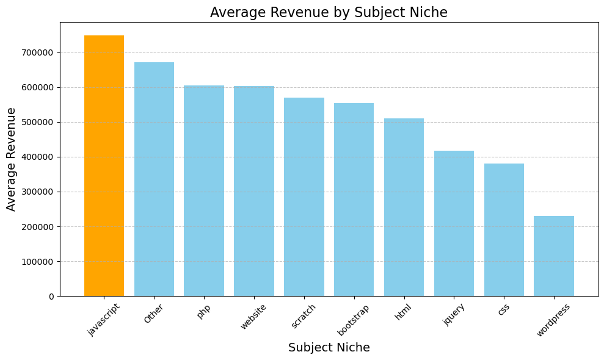

```python
colors = ['orange' if niche == 'javascript' else 'skyblue' for niche in average_revenue_per_niche['Subject Niche']]

plt.figure(figsize=(10, 6))
plt.bar(
    average_revenue_per_niche['Subject Niche'],
    average_revenue_per_niche['Average Revenue'],
    color=colors
)
plt.title('Average Revenue by Subject Niche', fontsize=16)
plt.xlabel('Subject Niche', fontsize=14)
plt.ylabel('Average Revenue', fontsize=14)
plt.xticks(rotation=45)
plt.grid(axis='y', linestyle='--', alpha=0.7)
plt.tight_layout()

plt.show()
```

we can easily conclude that javascript is both the most popular, and leads to the highest revenue on average.  
we also created a list of commonly used words we can use in our title.

## 4. which levels should be targeted with our course?

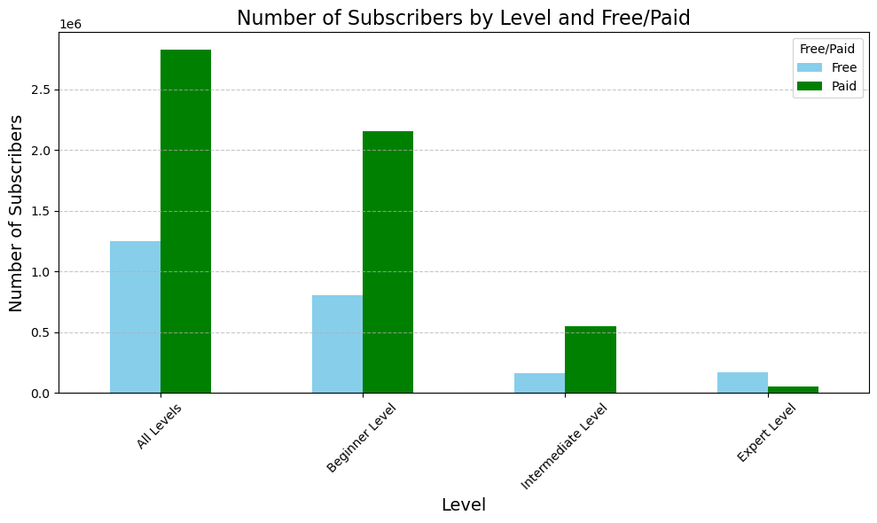

```python
subscribers_by_level = df[df['subject'] == 'Web Development'].groupby(['level', 'Free/Paid'])['num_subscribers'].sum().reset_index()

# Pivot the data for easier plotting
pivot_subscribers = subscribers_by_level.pivot(index='level', columns='Free/Paid', values='num_subscribers')
pivot_subscribers = pivot_subscribers.fillna(0)

pivot_subscribers['Total'] = pivot_subscribers.sum(axis=1)
pivot_subscribers = pivot_subscribers.sort_values(by='Total', ascending=False)
pivot_subscribers = pivot_subscribers.drop(columns=['Total'])

pivot_subscribers.plot(kind='bar', figsize=(10, 6), color=['skyblue', 'green'])

# Customize the plot
plt.title('Number of Subscribers by Level and Free/Paid', fontsize=16)
plt.xlabel('Level', fontsize=14)
plt.ylabel('Number of Subscribers', fontsize=14)
plt.xticks(rotation=45)
plt.legend(title='Free/Paid')
plt.grid(axis='y', linestyle='--', alpha=0.7)
plt.tight_layout()

# Show the plot
plt.show()
```

we can also check user sentiment across different levels

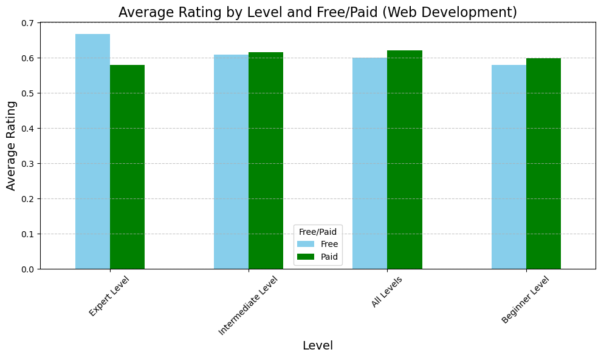

```python
rating_by_level = df.groupby(['level', 'Free/Paid'])['rating'].mean().reset_index()
pivot_rating = rating_by_level.pivot(index='level', columns='Free/Paid', values='rating')
pivot_rating['Total'] = pivot_rating.sum(axis=1)  # Add a total column
pivot_rating = pivot_rating.sort_values(by='Total', ascending=False)  # Sort by total height
pivot_rating = pivot_rating.drop(columns=['Total'])
pivot_rating = pivot_rating.fillna(0)
pivot_rating.plot(kind='bar', figsize=(10, 6), color=['skyblue', 'green'])
plt.title('Average Rating by Level and Free/Paid (Web Development)', fontsize=16)
plt.xlabel('Level', fontsize=14)
plt.ylabel('Average Rating', fontsize=14)
plt.xticks(rotation=45)
plt.legend(title='Free/Paid')
plt.grid(axis='y', linestyle='--', alpha=0.7)
plt.tight_layout()

plt.show()
```

we can see that the beginner and 'all levels' have the highest demand, and the expert level, besides having almost a neglegeble user base, has a higher appreciation for free courses. next we'll calculate the price per hour of content to figure out where we can profit the most for our time.

```python
df['lecture_duration'] = df['content_duration'] / df['num_lectures'] # maybe delete later
df['lecture_duration'] = df['lecture_duration'].fillna(0)  # maybe delete later
df_web_dev = df[df['subject'] == 'Web Development']
```

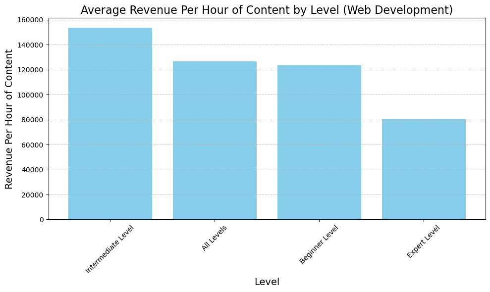

```python
df_web_dev['revenue_per_hour'] = df_web_dev['revenue'] / df_web_dev['content_duration']
df_web_dev['revenue_per_hour'] = df_web_dev['revenue_per_hour'].fillna(0)

# Group data by 'level' to calculate the average revenue per hour of content
revenue_per_hour_by_level = df_web_dev.groupby('level')['revenue_per_hour'].mean().reset_index()
revenue_per_hour_by_level = revenue_per_hour_by_level.sort_values(by='revenue_per_hour', ascending=False)

# Plot
plt.figure(figsize=(10, 6))
plt.bar(
    revenue_per_hour_by_level['level'],
    revenue_per_hour_by_level['revenue_per_hour'],
    color='skyblue'
)

plt.title('Average Revenue Per Hour of Content by Level (Web Development)', fontsize=16)
plt.xlabel('Level', fontsize=14)
plt.ylabel('Revenue Per Hour of Content', fontsize=14)
plt.xticks(rotation=45)
plt.grid(axis='y', linestyle='--', alpha=0.7)
plt.tight_layout()
plt.show()
```

the intermediate is the highest and the expert is, surprisingly, by far the lowest.  
my conclusion is that people in general do not reach the the expert level, and those who do, prefer free or high value courses.  
therefore we need to focus on beginner, intermediate and all-level courses, while considering a free expert level course to drive up exposure and user reception. we cannot preform the full cost analysis from this data but it's a fun idea worth considering.

## 5. how should we price our course in order to maximize revenue?

binning the prices allows us to compare price ranges, leading to less specific results, but allows us to view a cearer picture of revenue distribution, and leaves space for future flexibility.

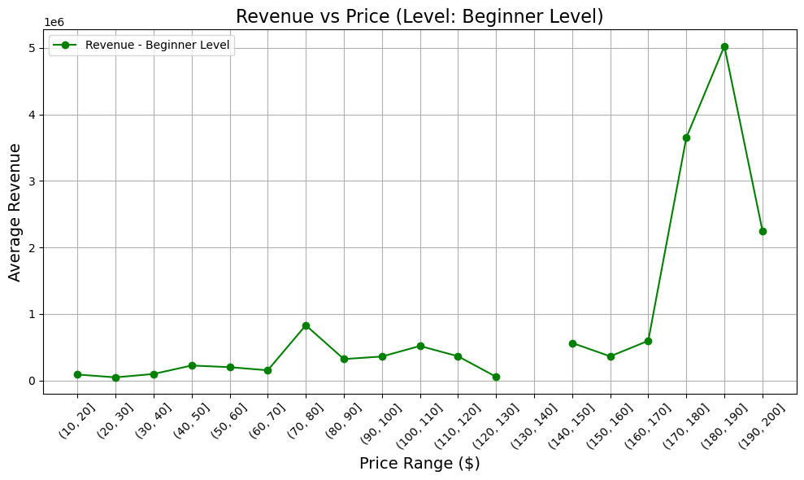

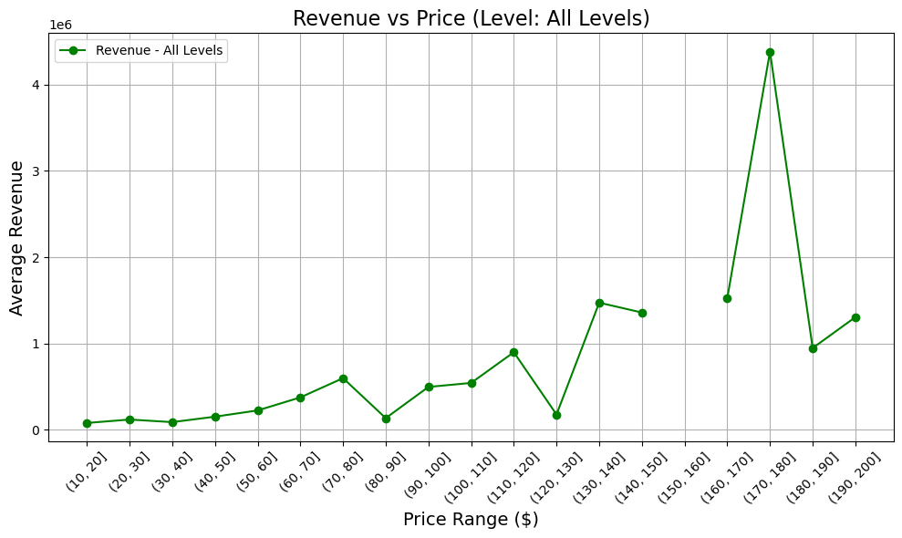

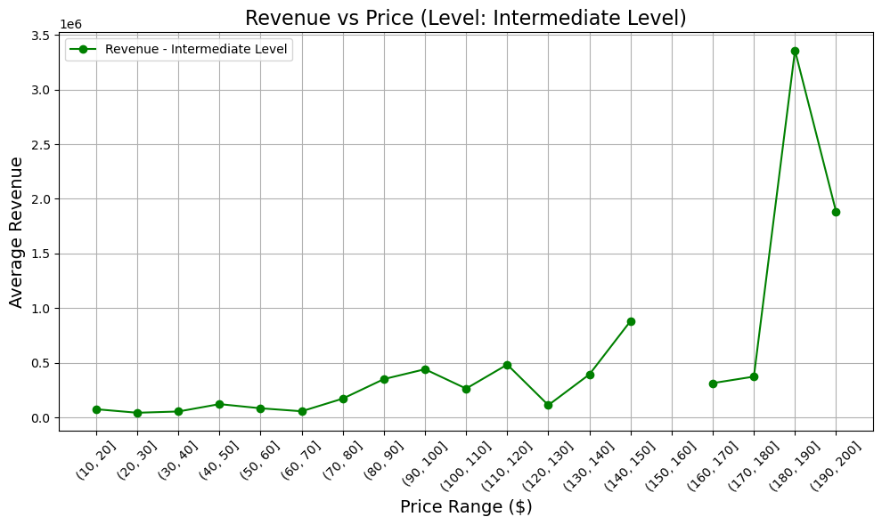

```python
# Bin prices
df_web_dev['price_bin'] = pd.cut(df_web_dev['price'], bins=range(0, 201, 10))
levels = df_web_dev['level'].unique()
levels = levels[levels != 'Expert Level']

# Loop through each level and see revenue trends
for level in levels:
    df_level = df_web_dev[df_web_dev['level'] == level]

    price_analysis = df_level.groupby('price_bin').agg(
        avg_revenue=('revenue', 'mean')
    ).reset_index()

    plt.figure(figsize=(10, 6))
    plt.plot(
        price_analysis['price_bin'].astype(str),
        price_analysis['avg_revenue'],
        marker='o',
        label=f'Revenue - {level}',
        color='green'
    )
    plt.title(f'Revenue vs Price (Level: {level})', fontsize=16)
    plt.xlabel('Price Range ($)', fontsize=14)
    plt.ylabel('Average Revenue', fontsize=14)
    plt.grid()
    plt.xticks(rotation=45)
    plt.legend()
    plt.tight_layout()
    plt.show()
```

# conclusions

- creating a course in web-development focusing on javascript can expose us to the largest audience base and lead to higher revenue.
- user engagement is positive, but should not be a big focus point.
- the optimal price ranges for each level are: beginner: 180-190  
  intermediate: 180-190  
  all levels: 170-180

the expert level is more complicated due to smaller case count and data imbalance. it is also less profitable than the others, so i'd recommend avoiding it unless the positive exposure from it can lead to better reception and larger adoptation of the lower level courses.